# Modeling and prediction for movies

## Setup

### Load packages

```r
library(ggplot2)
library(dplyr)
library(statsr)
library(broom)
library(moderndive)
library(tidyr)
library(readr)
library(knitr)
library(skimr)
library(GGally)
library(corrplot)
library(gridExtra)
```

### Load data

```r
#load("movies.Rdata")
movies <- get(load("Data/movies.RData"))
```

## Part 1: Data

- Let’ take a look at the data and try to get some insights

```r
head(movies)
```

| title | title_type | genre | runtime | mpaa_rating | studio | thtr_rel_year | thtr_rel_month | thtr_rel_day | dvd_rel_year | dvd_rel_month | dvd_rel_day | imdb_rating | imdb_num_votes | critics_rating | critics_score | audience_rating | audience_score | best_pic_nom | best_pic_win | best_actor_win | best_actress_win | best_dir_win | top200_box | director | actor1 | actor2 | actor3 | actor4 | actor5 | … |
| --- | --- | --- | --- | --- | --- | --- | --- | --- | --- | --- | --- | --- | --- | --- | --- | --- | --- | --- | --- | --- | --- | --- | --- | --- | --- | --- | --- | --- | --- | --- |
| Filly Brown | Feature Film | Drama | 80 | R | Indomina Media Inc. | 2013 | 4 | 19 | 2013 | 7 | 30 | 5.5 | 899 | Rotten | 45 | Upright | 73 | no | no | no | no | no | no | Michael D. Olmos | Gina Rodriguez | Jenni Rivera | Lou Diamond Phillips | Emilio Rivera | Joseph Julian Soria | … |
| The Dish | Feature Film | Drama | 101 | PG-13 | Warner Bros. Pictures | 2001 | 3 | 14 | 2001 | 8 | 28 | 7.3 | 12285 | Certified Fresh | 96 | Upright | 81 | no | no | no | no | no | no | Rob Sitch | Sam Neill | Kevin Harrington | Patrick Warburton | Tom Long | Genevieve Mooy | … |
| Waiting for Guffman | Feature Film | Comedy | 84 | R | Sony Pictures Classics | 1996 | 8 | 21 | 2001 | 8 | 21 | 7.6 | 22381 | Certified Fresh | 91 | Upright | 91 | no | no | no | no | no | no | Christopher Guest | Christopher Guest | Catherine O'Hara | Parker Posey | Eugene Levy | Bob Balaban | … |
| The Age of Innocence | Feature Film | Drama | 139 | PG | Columbia Pictures | 1993 | 10 | 1 | 2001 | 11 | 6 | 7.2 | 35096 | Certified Fresh | 80 | Upright | 76 | no | no | yes | no | yes | no | Martin Scorsese | Daniel Day-Lewis | Michelle Pfeiffer | Winona Ryder | Richard E. Grant | Alec McCowen | … |
| Malevolence | Feature Film | Horror | 90 | R | Anchor Bay Entertainment | 2004 | 9 | 10 | 2005 | 4 | 19 | 5.1 | 2386 | Rotten | 33 | Spilled | 27 | no | no | no | no | no | no | Stevan Mena | Samantha Dark | R. Brandon Johnson | Brandon Johnson | Heather Magee | Richard Glover | … |
| Old Partner | Documentary | Documentary | 78 | Unrated | Shcalo Media Group | 2009 | 1 | 15 | 2010 | 4 | 20 | 7.8 | 333 | Fresh | 91 | Upright | 86 | no | no | no | no | no | no | Chung-ryoul Lee | Choi Won-kyun | Lee Sam-soon | Moo | NA | NA | … |

[output not shown]

```r
glimpse(movies)
```

```
## Observations: 651
## Variables: 32
## $ title            <chr> "Filly Brown", "The Dish", "Waiting for Guffman", ...
## $ title_type       <fct> Feature Film, Feature Film, Feature Film, Feature ...
## $ genre            <fct> Drama, Drama, Comedy, Drama, Horror, Documentary, ...
## $ runtime          <dbl> 80, 101, 84, 139, 90, 78, 142, 93, 88, 119, 127, 1...
## $ mpaa_rating      <fct> R, PG-13, R, PG, R, Unrated, PG-13, R, Unrated, Un...
## $ studio           <fct> Indomina Media Inc., Warner Bros. Pictures, Sony P...
## $ thtr_rel_year    <dbl> 2013, 2001, 1996, 1993, 2004, 2009, 1986, 1996, 20...
## $ thtr_rel_month   <dbl> 4, 3, 8, 10, 9, 1, 1, 11, 9, 3, 6, 12, 1, 9, 6, 8,...
## $ thtr_rel_day     <dbl> 19, 14, 21, 1, 10, 15, 1, 8, 7, 2, 19, 18, 4, 23, ...
## $ dvd_rel_year     <dbl> 2013, 2001, 2001, 2001, 2005, 2010, 2003, 2004, 20...
## $ dvd_rel_month    <dbl> 7, 8, 8, 11, 4, 4, 2, 3, 1, 8, 5, 9, 7, 2, 3, 12, ...
## $ dvd_rel_day      <dbl> 30, 28, 21, 6, 19, 20, 18, 2, 21, 14, 1, 23, 9, 13...
## $ imdb_rating      <dbl> 5.5, 7.3, 7.6, 7.2, 5.1, 7.8, 7.2, 5.5, 7.5, 6.6, ...
```

[output cut: 19 more lines]

The `movies` dataset has 651 observations and 32 variables. After examining the data codebook, I decided to omit some variables since they make no relevance to my analysis

```r
movies <- movies %>%
  select(-c(rt_url, imdb_url, actor1, actor2, actor3, actor4, actor5, director,dvd_rel_day,
            dvd_rel_month, thtr_rel_month, thtr_rel_day, best_pic_nom))

# check for changes
glimpse(movies)
```

```
## Observations: 651
## Variables: 19
## $ title            <chr> "Filly Brown", "The Dish", "Waiting for Guffman", ...
## $ title_type       <fct> Feature Film, Feature Film, Feature Film, Feature ...
## $ genre            <fct> Drama, Drama, Comedy, Drama, Horror, Documentary, ...
## $ runtime          <dbl> 80, 101, 84, 139, 90, 78, 142, 93, 88, 119, 127, 1...
## $ mpaa_rating      <fct> R, PG-13, R, PG, R, Unrated, PG-13, R, Unrated, Un...
## $ studio           <fct> Indomina Media Inc., Warner Bros. Pictures, Sony P...
## $ thtr_rel_year    <dbl> 2013, 2001, 1996, 1993, 2004, 2009, 1986, 1996, 20...
## $ dvd_rel_year     <dbl> 2013, 2001, 2001, 2001, 2005, 2010, 2003, 2004, 20...
## $ imdb_rating      <dbl> 5.5, 7.3, 7.6, 7.2, 5.1, 7.8, 7.2, 5.5, 7.5, 6.6, ...
## $ imdb_num_votes   <int> 899, 12285, 22381, 35096, 2386, 333, 5016, 2272, 8...
## $ critics_rating   <fct> Rotten, Certified Fresh, Certified Fresh, Certifie...
## $ critics_score    <dbl> 45, 96, 91, 80, 33, 91, 57, 17, 90, 83, 89, 67, 80...
## $ audience_rating  <fct> Upright, Upright, Upright, Upright, Spilled, Uprig...
## $ audience_score   <dbl> 73, 81, 91, 76, 27, 86, 76, 47, 89, 66, 75, 46, 89...
## $ best_pic_win     <fct> no, no, no, no, no, no, no, no, no, no, no, no, no...
## $ best_actor_win   <fct> no, no, no, yes, no, no, no, yes, no, no, yes, no,...
## $ best_actress_win <fct> no, no, no, no, no, no, no, no, no, no, no, no, ye...
## $ best_dir_win     <fct> no, no, no, yes, no, no, no, no, no, no, no, no, n...
## $ top200_box       <fct> no, no, no, no, no, no, no, no, no, no, yes, no, n...
```

- Since these data resulted from a random process, we can make generalizations using the data in hands. However, we should be careful to not extrapolate our results beyond the range of our data points (e.g. we should be very cautious when making predictions about movies released before 1970 or after 2014).
- This data did not come out from experimental settings. Since no random assignment was used in generating these data, we cannot infer causality from our analysis; we can only state associations and correlations between different variables.

## Part 2: Research question

My research question is: **Which movies’ characteristics do have the highest influence on predicting ratings on IMDB website?**

## Part 3: Exploratory data analysis

Let’s again have a look into our dataset

```r
# Using skim fucntion, I will try to know more details about the dataset
skim(movies)
```

Data summary

| Name | movies |
| --- | --- |
| Number of rows | 651 |
| Number of columns | 19 |
| _______________________ |  |
| Column type frequency: |  |
| character | 1 |
| factor | 11 |
| numeric | 7 |
| ________________________ |  |
| Group variables | None |

**Variable type: character**

| skim_variable | n_missing | complete_rate | min | max | empty | n_unique | whitespace |
| --- | --- | --- | --- | --- | --- | --- | --- |
| title | 0 | 1 | 3 | 70 | 0 | 647 | 0 |

**Variable type: factor**

| skim_variable | n_missing | complete_rate | ordered | n_unique | top_counts |
| --- | --- | --- | --- | --- | --- |
| title_type | 0 | 1.00 | FALSE | 3 | Fea: 591, Doc: 55, TV : 5 |
| genre | 0 | 1.00 | FALSE | 11 | Dra: 305, Com: 87, Act: 65, Mys: 59 |
| mpaa_rating | 0 | 1.00 | FALSE | 6 | R: 329, PG-: 133, PG: 118, Unr: 50 |
| studio | 8 | 0.99 | FALSE | 211 | Par: 37, War: 30, Son: 27, Uni: 23 |
| critics_rating | 0 | 1.00 | FALSE | 3 | Rot: 307, Fre: 209, Cer: 135 |
| audience_rating | 0 | 1.00 | FALSE | 2 | Upr: 376, Spi: 275 |
| best_pic_win | 0 | 1.00 | FALSE | 2 | no: 644, yes: 7 |
| best_actor_win | 0 | 1.00 | FALSE | 2 | no: 558, yes: 93 |
| best_actress_win | 0 | 1.00 | FALSE | 2 | no: 579, yes: 72 |
| best_dir_win | 0 | 1.00 | FALSE | 2 | no: 608, yes: 43 |
| top200_box | 0 | 1.00 | FALSE | 2 | no: 636, yes: 15 |

**Variable type: numeric**

| skim_variable | n_missing | complete_rate | mean | sd | p0 | p25 | p50 | p75 | p100 | hist |
| --- | --- | --- | --- | --- | --- | --- | --- | --- | --- | --- |
| runtime | 1 | 1.00 | 105.82 | 19.45 | 39.0 | 92.0 | 103.0 | 115.75 | 267 | ▁▇▁▁▁ |
| thtr_rel_year | 0 | 1.00 | 1997.94 | 10.97 | 1970.0 | 1990.0 | 2000.0 | 2007.00 | 2014 | ▂▃▆▆▇ |
| dvd_rel_year | 8 | 0.99 | 2004.43 | 4.64 | 1991.0 | 2001.0 | 2004.0 | 2008.00 | 2015 | ▁▃▇▃▃ |
| imdb_rating | 0 | 1.00 | 6.49 | 1.08 | 1.9 | 5.9 | 6.6 | 7.30 | 9 | ▁▁▃▇▂ |
| imdb_num_votes | 0 | 1.00 | 57532.98 | 112124.39 | 180.0 | 4545.5 | 15116.0 | 58300.50 | 893008 | ▇▁▁▁▁ |
| critics_score | 0 | 1.00 | 57.69 | 28.40 | 1.0 | 33.0 | 61.0 | 83.00 | 100 | ▅▅▅▆▇ |
| audience_score | 0 | 1.00 | 62.36 | 20.22 | 11.0 | 46.0 | 65.0 | 80.00 | 97 | ▂▅▆▇▇ |

I want first to examine how our both response variables, `imdb_rating` and `critics_score` relate to each other.

[figure not shown]

```r
ggplot(movies, aes(x = imdb_rating, y = critics_score)) + geom_jitter(alpha = 0.2) + scale_x_continuous(breaks = seq(0,10,1)) + facet_wrap(~genre) + theme_minimal() + labs(
  title = "IMDB vs Rotten Tomatoes Ratings",
  subtitle = "Data are faceted by movies' genres",
  x= "IMDB ratings (1 to 10)",
  y = "Rotten Tomatoes ratings (0 to 100)"
) + theme_bw() +theme(
  strip.text = element_text(color = "white", face = "bold", family = "serif"),
  strip.background = element_rect(fill ="gray60")
)
```

From the plot above, we can notice that the dataset has a lot of movies of both comedy and drama genres in comparison with other types of movies. Also, the positive strong relationship is as well more pronounced in these two kinds of movies as well.

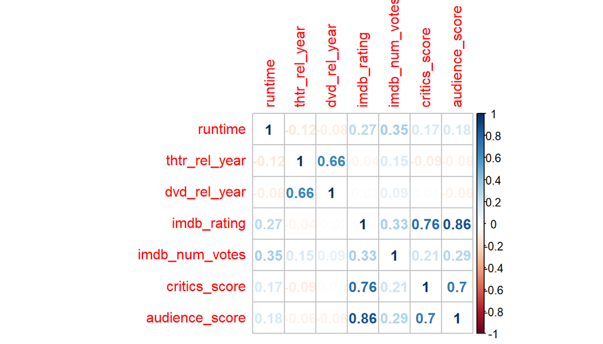

```r
# Plot a correlation matrix
corrplot(cor(na.omit(movies[,c(4,7,8,9,10,12,14)])), method = "number", type = "full")
```

Among our seven numerical variables, `imdb_rating` is moderately to strongly associated with `critics_score` $(r = 0.76)$ and `audience_score` $(r = 0.86)$. There is also some correlation, though weak, between `imdb_rating` and both `imdb_num_votes` and `runtime` with correlation coefficients of $(r = 0.33)$ and $(r = 0.27)$, respectively.

Now let’s try to understand how our categorical explanatory variables relate to our response variables through visualizations and numerical summaries.

I was wondering wheter ratings/scores can differ by movies genre, so let’s figure this out

```r
movies %>%
  group_by(genre) %>%
  summarise(avg_imdb = round(mean(imdb_rating),2), n =n()) %>%
  arrange(desc(avg_imdb))
```

| genre | avg_imdb | n |
| --- | --- | --- |
| Documentary | 7.65 | 52 |
| Musical & Performing Arts | 7.30 | 12 |
| Drama | 6.67 | 305 |
| Other | 6.63 | 16 |
| Art House & International | 6.61 | 14 |
| Mystery & Suspense | 6.48 | 59 |
| Action & Adventure | 5.97 | 65 |
| Animation | 5.90 | 9 |
| Horror | 5.76 | 23 |
| Science Fiction & Fantasy | 5.76 | 9 |

[output cut: 1 more lines]

[output not shown]

Interesting! For IMDB ratings, documentray movies got the highest score while comedy movies got the lowest. Nonetheless, there is a considerable difference in terms of the number of titles in both genres as well as the number of voters on IMDB website.

Now let’s try to figure out whether there is a difference between old movies and new movies and their ratings on Rotten Tomatoes

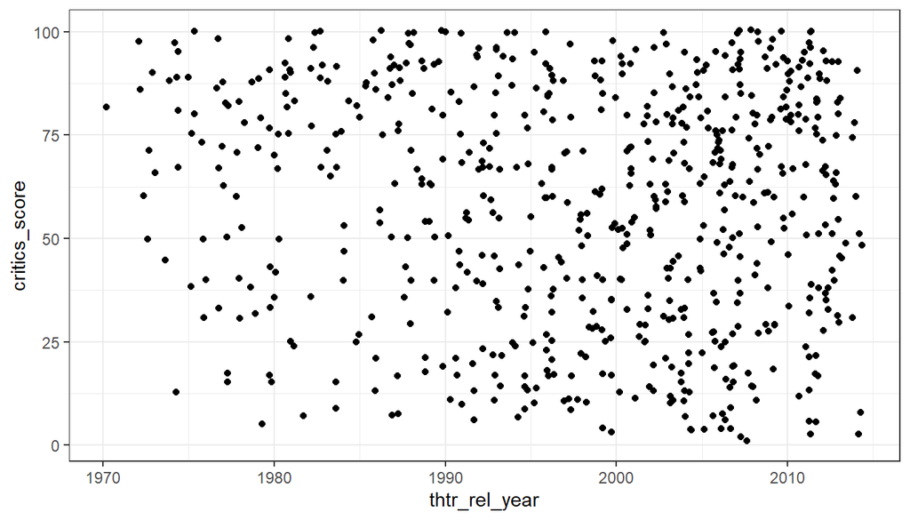

```r
ggplot(movies, aes(x = thtr_rel_year, y = critics_score)) + geom_jitter()+ theme_bw()
```

The scatter here is too random and noisy. It seems obvious that release year has nothing to do with critics score. What about IMDB ratings?

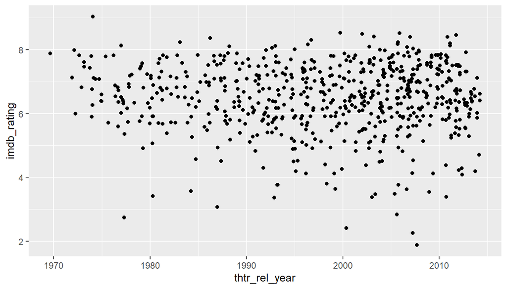

```r
ggplot(movies, aes(x = thtr_rel_year, y = imdb_rating)) + geom_jitter()
```

Well. We came to a conclusion here: years of movies’ release have nothing to do with IMDB ratings.

The last bumerical variable that I want to examine its relationship with our response variables is `runtime`.

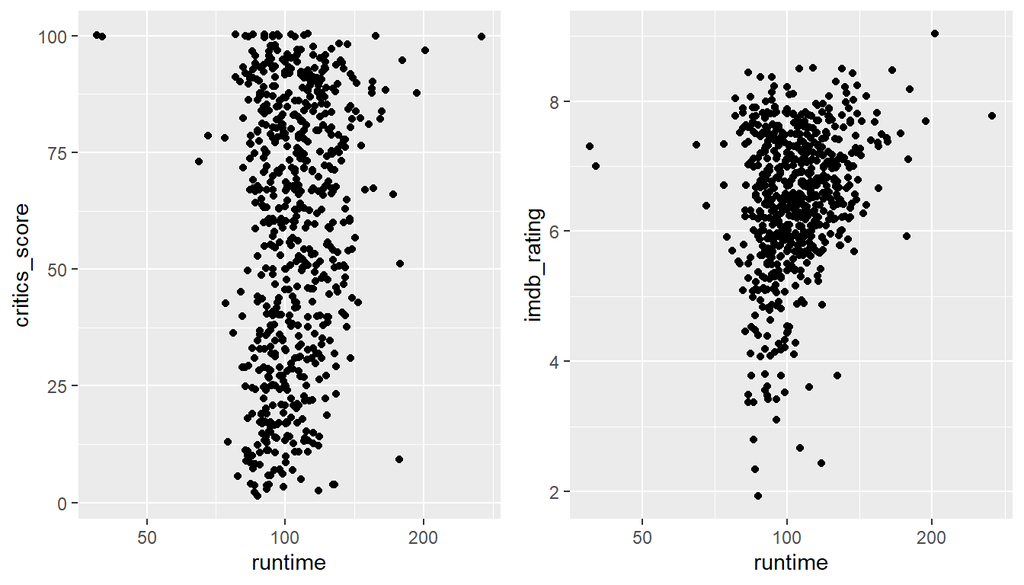

```r
p1 <- ggplot(movies, aes(x = runtime, y = critics_score)) + geom_jitter() + scale_x_log10()
p2 <- ggplot(movies, aes(x = runtime, y = imdb_rating)) + geom_jitter() + scale_x_log10()
grid.arrange(p1,p2, ncol = 2)
```

## Part 4: Modeling

### IMDB ratings model

- In this model, I will use `imdb_ratings` as a response variable.
- From our EDA, we observed how some variables are not well correlated with `imdb_ratings`. Nonetheless, I will incorporate almose all of them in the model. I will exclude the names of the studios `studio` and the names of the movies `title`. Also, I will only add one Rotten Tomatoes’ parameter to avoid colinearity.

```r
ImdbCrudeModel <- lm(data = movies, imdb_rating ~ title_type+ runtime + genre + mpaa_rating + thtr_rel_year + imdb_num_votes + critics_score + best_pic_win + best_actor_win + best_actress_win + best_dir_win + top200_box,)

#get the model output
summary(ImdbCrudeModel)
```

```
##
## Call:
## lm(formula = imdb_rating ~ title_type + runtime + genre + mpaa_rating +
##     thtr_rel_year + imdb_num_votes + critics_score + best_pic_win +
##     best_actor_win + best_actress_win + best_dir_win + top200_box,
##     data = movies)
##
## Residuals:
##      Min       1Q   Median       3Q      Max
## -2.84912 -0.32373  0.03714  0.38801  1.79199
##
## Coefficients:
##                                  Estimate Std. Error t value Pr(>|t|)
## (Intercept)                     1.164e+01  5.352e+00   2.175  0.02997 *
## title_typeFeature Film         -1.033e-01  2.383e-01  -0.433  0.66492
## title_typeTV Movie             -4.986e-01  3.731e-01  -1.336  0.18187
## runtime                         4.517e-03  1.575e-03   2.867  0.00428 **
## genreAnimation                 -2.696e-01  2.518e-01  -1.071  0.28471
## genreArt House & International  5.516e-01  1.935e-01   2.851  0.00450 **
## genreComedy                    -9.536e-02  1.071e-01  -0.891  0.37345
## genreDocumentary                7.326e-01  2.537e-01   2.887  0.00402 **
## genreDrama                      2.272e-01  9.424e-02   2.411  0.01622 *
## genreHorror                    -1.442e-01  1.594e-01  -0.905  0.36607
## genreMusical & Performing Arts  5.359e-01  2.183e-01   2.455  0.01436 *
## genreMystery & Suspense         1.474e-01  1.200e-01   1.229  0.21961
## genreOther                     -3.010e-03  1.818e-01  -0.017  0.98680
## genreScience Fiction & Fantasy -4.462e-01  2.270e-01  -1.966  0.04974 *
## mpaa_ratingNC-17               -5.749e-01  4.832e-01  -1.190  0.23460
## mpaa_ratingPG                  -2.223e-01  1.764e-01  -1.260  0.20822
## mpaa_ratingPG-13               -2.733e-01  1.854e-01  -1.474  0.14095
## mpaa_ratingR                   -1.706e-01  1.778e-01  -0.959  0.33770
## mpaa_ratingUnrated             -2.068e-01  2.069e-01  -0.999  0.31800
## thtr_rel_year                  -3.484e-03  2.666e-03  -1.307  0.19166
## imdb_num_votes                  2.178e-06  2.825e-07   7.709 5.05e-14 ***
## critics_score                   2.323e-02  1.086e-03  21.390  < 2e-16 ***
## best_pic_winyes                -2.933e-01  2.706e-01  -1.084  0.27881
## best_actor_winyes               8.346e-03  7.541e-02   0.111  0.91191
## best_actress_winyes            -1.748e-03  8.358e-02  -0.021  0.98332
## best_dir_winyes                 2.142e-02  1.100e-01   0.195  0.84562
## top200_boxyes                  -2.051e-01  1.788e-01  -1.147  0.25165
## ---
## Signif. codes:  0 '***' 0.001 '**' 0.01 '*' 0.05 '.' 0.1 ' ' 1
##
## Residual standard error: 0.6357 on 623 degrees of freedom
##   (1 observation deleted due to missingness)
## Multiple R-squared:  0.6704, Adjusted R-squared:  0.6566
## F-statistic: 48.73 on 26 and 623 DF,  p-value: < 2.2e-16
```

#### A. Selecting model based on p-value-based backward elimination:

- Next, I followed step-wise backward elimination technique based on p-values of the coefficients.
- The basic idea behind this method is to include all variables in hands into the model. Then, step by step, we remove the variable that has the highest p-value. Next, we re-run the model and repeat the same steps again until reaching a model whose all of its coefficients are statistically significant.
- The best model is shown below:

```r
p_imdb_model <- lm(data = movies, imdb_rating ~ runtime + genre  + imdb_num_votes + critics_score )

summary(p_imdb_model)
```

```
##
## Call:
## lm(formula = imdb_rating ~ runtime + genre + imdb_num_votes +
##     critics_score, data = movies)
##
## Residuals:
##     Min      1Q  Median      3Q     Max
## -2.9094 -0.3305  0.0380  0.3873  1.8059
##
## Coefficients:
##                                  Estimate Std. Error t value Pr(>|t|)
## (Intercept)                     4.381e+00  1.673e-01  26.185  < 2e-16 ***
## runtime                         4.350e-03  1.451e-03   2.997  0.00283 **
## genreAnimation                 -1.634e-01  2.272e-01  -0.719  0.47231
## genreArt House & International  5.454e-01  1.883e-01   2.896  0.00391 **
## genreComedy                    -1.161e-01  1.046e-01  -1.110  0.26758
## genreDocumentary                7.861e-01  1.304e-01   6.029 2.80e-09 ***
## genreDrama                      2.118e-01  9.017e-02   2.349  0.01915 *
## genreHorror                    -1.172e-01  1.551e-01  -0.756  0.45006
## genreMusical & Performing Arts  5.548e-01  2.043e-01   2.716  0.00680 **
## genreMystery & Suspense         1.578e-01  1.152e-01   1.369  0.17137
## genreOther                     -1.039e-02  1.787e-01  -0.058  0.95369
## genreScience Fiction & Fantasy -4.185e-01  2.260e-01  -1.852  0.06446 .
## imdb_num_votes                  1.938e-06  2.483e-07   7.804 2.48e-14 ***
## critics_score                   2.374e-02  1.018e-03  23.315  < 2e-16 ***
## ---
## Signif. codes:  0 '***' 0.001 '**' 0.01 '*' 0.05 '.' 0.1 ' ' 1
##
## Residual standard error: 0.6347 on 636 degrees of freedom
##   (1 observation deleted due to missingness)
## Multiple R-squared:  0.6646, Adjusted R-squared:  0.6577
## F-statistic: 96.92 on 13 and 636 DF,  p-value: < 2.2e-16
```

```r
moderndive::get_regression_table(p_imdb_model)
```

| term | estimate | std_error | statistic | p_value | lower_ci | upper_ci |
| --- | --- | --- | --- | --- | --- | --- |
| intercept | 4.381 | 0.167 | 26.185 | 0.000 | 4.053 | 4.710 |
| runtime | 0.004 | 0.001 | 2.997 | 0.003 | 0.001 | 0.007 |
| genreAnimation | -0.163 | 0.227 | -0.719 | 0.472 | -0.610 | 0.283 |
| genreArt House & International | 0.545 | 0.188 | 2.896 | 0.004 | 0.176 | 0.915 |
| genreComedy | -0.116 | 0.105 | -1.110 | 0.268 | -0.322 | 0.089 |
| genreDocumentary | 0.786 | 0.130 | 6.029 | 0.000 | 0.530 | 1.042 |
| genreDrama | 0.212 | 0.090 | 2.349 | 0.019 | 0.035 | 0.389 |
| genreHorror | -0.117 | 0.155 | -0.756 | 0.450 | -0.422 | 0.187 |
| genreMusical & Performing Arts | 0.555 | 0.204 | 2.716 | 0.007 | 0.154 | 0.956 |
| genreMystery & Suspense | 0.158 | 0.115 | 1.369 | 0.171 | -0.068 | 0.384 |

[output cut: 4 more lines]

[output not shown]

#### B. Selecting model based on adjusted $R^2$ -based backward elimination:

- Also, I used stepwise backward elimination but based on adjusted R-squared this time.
- The basic idea behind this method is to include all variables in hands into the model. Then, step by step, we remove variables one by one and re-run to see what happens to the adjusted $R^2$ value. We remove a variable from the model if its removal did no reduce or, in fact, increased the adjusted $R^2$ value.
- The best model is shown below:

```r
Imdb_radjust <- lm(data = movies, imdb_rating ~  runtime + genre + thtr_rel_year + imdb_num_votes + critics_score + best_pic_win + top200_box)

#get the model output
summary(Imdb_radjust)
```

```
##
## Call:
## lm(formula = imdb_rating ~ runtime + genre + thtr_rel_year +
##     imdb_num_votes + critics_score + best_pic_win + top200_box,
##     data = movies)
##
## Residuals:
##      Min       1Q   Median       3Q      Max
## -2.89377 -0.30834  0.03164  0.38719  1.82150
##
## Coefficients:
##                                  Estimate Std. Error t value Pr(>|t|)
## (Intercept)                     1.248e+01  4.936e+00   2.529  0.01168 *
## runtime                         4.212e-03  1.472e-03   2.861  0.00436 **
## genreAnimation                 -1.477e-01  2.277e-01  -0.649  0.51686
## genreArt House & International  5.572e-01  1.887e-01   2.953  0.00327 **
## genreComedy                    -1.112e-01  1.052e-01  -1.058  0.29065
## genreDocumentary                8.228e-01  1.336e-01   6.159  1.3e-09 ***
## genreDrama                      2.165e-01  9.108e-02   2.377  0.01775 *
## genreHorror                    -1.267e-01  1.554e-01  -0.816  0.41494
## genreMusical & Performing Arts  5.677e-01  2.051e-01   2.768  0.00580 **
## genreMystery & Suspense         1.603e-01  1.160e-01   1.383  0.16727
## genreOther                     -4.379e-02  1.792e-01  -0.244  0.80706
## genreScience Fiction & Fantasy -4.318e-01  2.260e-01  -1.910  0.05653 .
## thtr_rel_year                  -4.049e-03  2.459e-03  -1.647  0.10013
## imdb_num_votes                  2.196e-06  2.767e-07   7.936  9.5e-15 ***
## critics_score                   2.354e-02  1.037e-03  22.693  < 2e-16 ***
## best_pic_winyes                -2.785e-01  2.580e-01  -1.079  0.28079
## top200_boxyes                  -2.026e-01  1.760e-01  -1.151  0.25007
## ---
## Signif. codes:  0 '***' 0.001 '**' 0.01 '*' 0.05 '.' 0.1 ' ' 1
##
## Residual standard error: 0.634 on 633 degrees of freedom
##   (1 observation deleted due to missingness)
## Multiple R-squared:  0.6669, Adjusted R-squared:  0.6585
## F-statistic: 79.22 on 16 and 633 DF,  p-value: < 2.2e-16
```

```r
get_regression_table(Imdb_radjust)
```

| term | estimate | std_error | statistic | p_value | lower_ci | upper_ci |
| --- | --- | --- | --- | --- | --- | --- |
| intercept | 12.484 | 4.936 | 2.529 | 0.012 | 2.791 | 22.177 |
| runtime | 0.004 | 0.001 | 2.861 | 0.004 | 0.001 | 0.007 |
| genreAnimation | -0.148 | 0.228 | -0.649 | 0.517 | -0.595 | 0.299 |
| genreArt House & International | 0.557 | 0.189 | 2.953 | 0.003 | 0.187 | 0.928 |
| genreComedy | -0.111 | 0.105 | -1.058 | 0.291 | -0.318 | 0.095 |
| genreDocumentary | 0.823 | 0.134 | 6.159 | 0.000 | 0.560 | 1.085 |
| genreDrama | 0.217 | 0.091 | 2.377 | 0.018 | 0.038 | 0.395 |
| genreHorror | -0.127 | 0.155 | -0.816 | 0.415 | -0.432 | 0.178 |
| genreMusical & Performing Arts | 0.568 | 0.205 | 2.768 | 0.006 | 0.165 | 0.970 |
| genreMystery & Suspense | 0.160 | 0.116 | 1.383 | 0.167 | -0.067 | 0.388 |

[output cut: 7 more lines]

[output not shown]

We can see that both models have very close adjusted $R^2$ values. However, we will go with the second model, `Imdb_radjust`, since it has higher adjusted $R^2$.

### Model diagnostics

- Create a detailed summary for the model

```r
model_details <- augment(Imdb_radjust)

#observe
model_details
```

| .rownames | imdb_rating | runtime | genre | thtr_rel_year | imdb_num_votes | critics_score | best_pic_win | top200_box | .fitted | .se.fit | .resid | .hat | .sigma | .cooksd | .std.resid |
| --- | --- | --- | --- | --- | --- | --- | --- | --- | --- | --- | --- | --- | --- | --- | --- |
| 1 | 5.5 | 80 | Drama | 2013 | 899 | 45 | no | no | 5.948778 | 0.06586137 | -0.448777983 | 0.010792977 | 0.6342049 | 3.251328e-04 | -0.711750568 |
| 2 | 7.3 | 101 | Drama | 2001 | 12285 | 96 | no | no | 7.311411 | 0.05739858 | -0.011411427 | 0.008197511 | 0.6344587 | 1.588336e-07 | -0.018074539 |
| 3 | 7.6 | 84 | Comedy | 1996 | 22381 | 91 | no | no | 6.836777 | 0.08837514 | 0.763222795 | 0.019433005 | 0.6337176 | 1.723133e-03 | 1.215773219 |
| 4 | 7.2 | 139 | Drama | 1993 | 35096 | 80 | no | no | 7.177280 | 0.05975970 | 0.022720296 | 0.008885801 | 0.6344582 | 6.834520e-07 | 0.035999131 |
| 5 | 5.1 | 90 | Horror | 2004 | 2386 | 33 | no | no | 5.404863 | 0.13432458 | -0.304862686 | 0.044894249 | 0.6343375 | 6.694639e-04 | -0.492060402 |
| 6 | 7.8 | 78 | Documentary | 2009 | 333 | 91 | no | no | 7.644457 | 0.09366441 | 0.155542809 | 0.021828755 | 0.6344280 | 8.078484e-05 | 0.248074638 |
| 7 | 7.2 | 142 | Drama | 1986 | 5016 | 57 | no | no | 6.610744 | 0.06604655 | 0.589255644 | 0.010853756 | 0.6340210 | 5.637640e-04 | 0.934573308 |
| 8 | 5.5 | 93 | Drama | 1996 | 2272 | 17 | no | no | 5.416216 | 0.06136268 | 0.083783810 | 0.009368896 | 0.6344500 | 9.808793e-06 | 0.132783466 |
| 9 | 7.5 | 88 | Documentary | 2012 | 880 | 90 | no | no | 7.652088 | 0.09217335 | -0.152087661 | 0.021139293 | 0.6344294 | 7.469086e-05 | -0.242478596 |
| 10 | 6.6 | 119 | Drama | 2012 | 12496 | 83 | no | no | 7.037114 | 0.06525730 | -0.437113978 | 0.010595902 | 0.6342180 | 3.026988e-04 | -0.693182703 |

[output cut: 640 more lines]

[output not shown]

#### **1- Check for linearity**

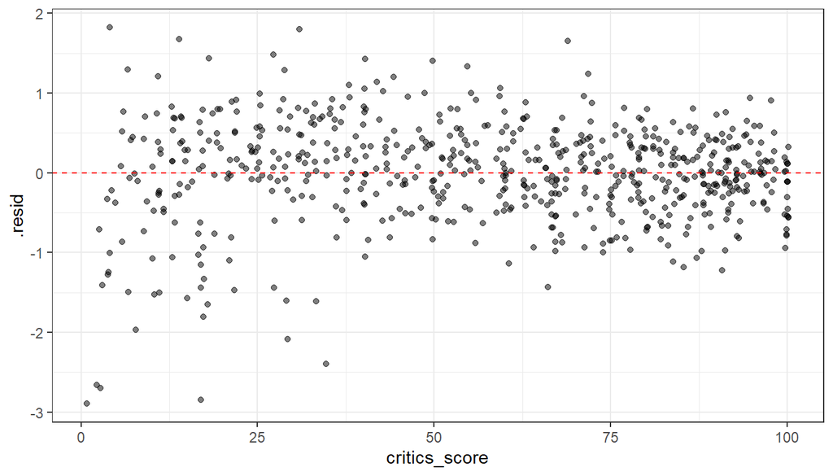

```r
# Check for critics score
ggplot(model_details, aes(x = critics_score, y= .resid)) + geom_jitter(alpha = 0.5) + theme_bw() + geom_hline(yintercept = 0, color = "red", linetype = "dashed")
```

**Comment**: I think that we can say the points are fairly randomy scattered around 0. Therefore, we can say that relationship is linear

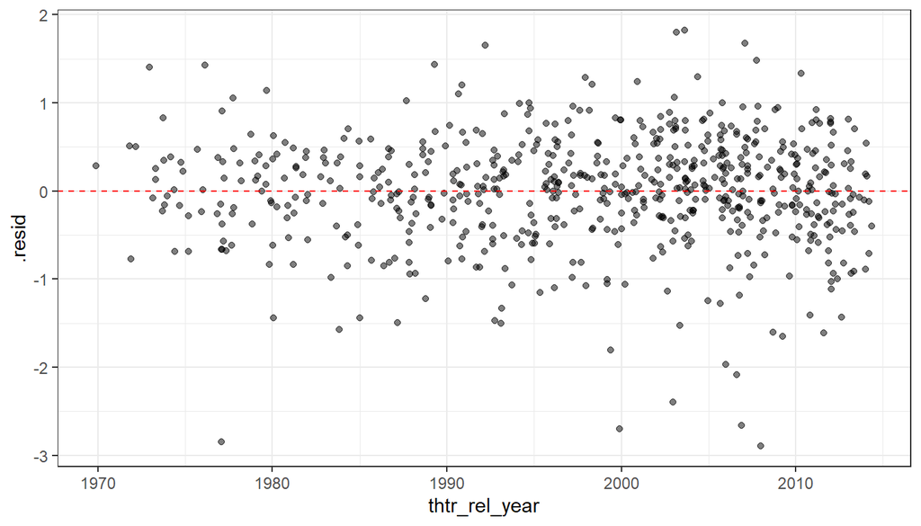

```r
# Check for release year
ggplot(model_details, aes(x = thtr_rel_year, y= .resid)) + geom_jitter(alpha = 0.5) + theme_bw() + geom_hline(yintercept = 0, color = "red", linetype = "dashed")
```

**Comment**: I think that we can say the points are fairly randomy scattered around 0. Therefore, we can say that relationship is linear

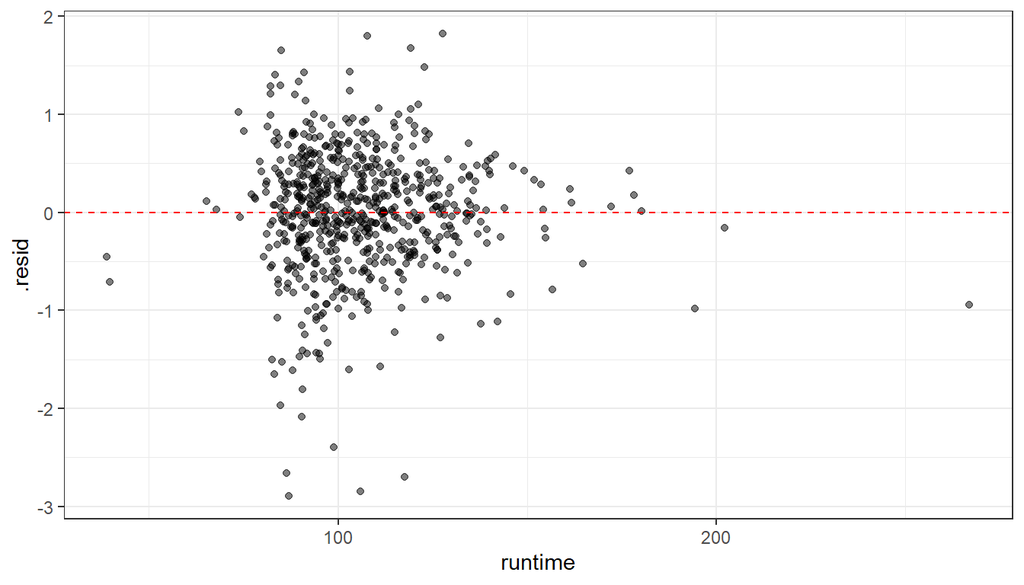

```r
# Check for movies runtime
ggplot(model_details, aes(x = runtime, y= .resid)) + geom_jitter(alpha = 0.5) + theme_bw() + geom_hline(yintercept = 0, color = "red", linetype = "dashed")
```

**Comment**: I think that we can say the points are fairly randomy scattered around 0. Therefore, we can say that relationship is linear

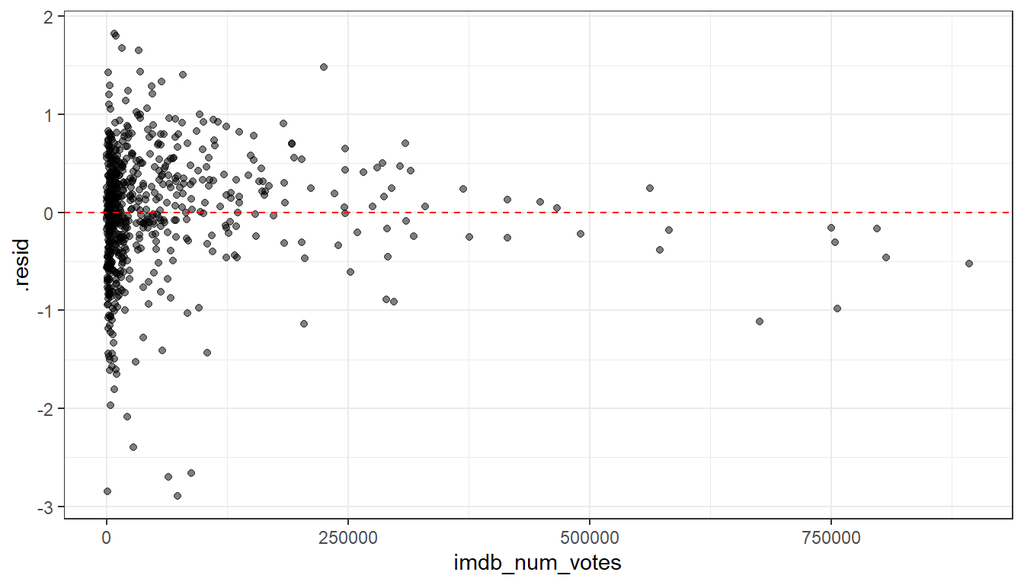

```r
# Check for number of votes
ggplot(model_details, aes(x = imdb_num_votes, y= .resid)) + geom_jitter(alpha = 0.5) + theme_bw() + geom_hline(yintercept = 0, color = "red", linetype = "dashed")
```

- The condition of random scatter around zero is clearly violated for the number of voters variable.
- **Conclusion**: Except for number of voters, all numerical variables show fairly random sactter around zero

#### **2- Check for normal residuals**

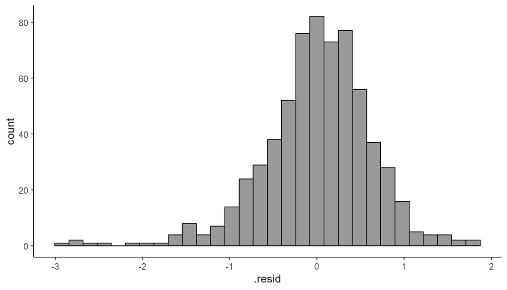

```r
norm_resid_plot1 <- ggplot(model_details, aes(x = .resid)) + geom_histogram(color="black", fill="gray60") + theme_classic()

#show histogram
norm_resid_plot1
```

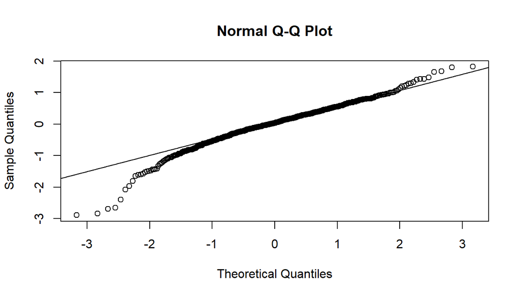

```r
#show qq plot
qqnorm(model_details$.resid)
qqline(model_details$.resid)
```

- **Comment**: Generally speaking, the second condition is also met.

#### **3- Check for constant variability of residulas**

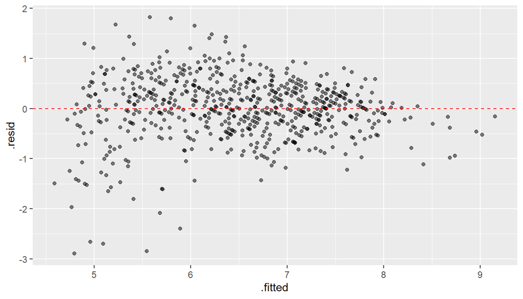

```r
ggplot(model_details, aes(x = .fitted, y= .resid)) + geom_point(alpha = 0.5) + geom_hline(yintercept = 0, color="red", linetype = "dashed")
```

- **Comment**: From the scatterplot above, we can see that residuals are almost equally variable for different fitted values of the response variable

#### **4- Check for independence among observations:**

Since each observation represents a different movies, there is reason to assume any kind of relationship among observations. Hence, we can say that observations are *independent*.

- Our final model is as follows:

$$\widehat{IMDB score} =12.484 + 0.004 \times runtime -0.148 \times 1 (genre:Animation)+ 0.557 \times 1(genre:Art)$$
$$-0.111 \times 1(genre:Comedy)+0.823 \times 1(genre:Documentary) +0.217 \times 1(genre: Drama)$$
$$-0.127 \times1(genre:Horror) + 0.568\times1(genre:Musical)
+0.16 \times 1(genre:Mystery)$$
$$-0.044\times1(genre:Other) -0.432 \times1(genre:SciFi) - 0.004\times release year$$
$$+ 0 \times numberof votes
+ 0.024\times critics score- 0.279 \times 1 (WonBestPic: yes) - 0.203 \times 1(Top200Box: yes)$$

### Interpretation of model coefficients

- All other variables held constant, for each one additional minute in movies’ `runtime`, the IMDB rating is expected to go up, on average, by 0.004 on ratings scale out of 10.
- All other variables held constant, documenary, art, drama, musical, and mystery movies have on average higher IMDB ratings when compared to action and adventures movies (reference value).
- All other variables held constant, animcation, comdey, horror, science fiction movies and movies categorized as “other” have on average lower IMDB ratings when compared to action and adventures movies (reference value).
- All other variables held constant, for each one additional point in Rotten Tomatoes’ `critics_score` ratings, the IMDB rating is expected to go up, on average, by 0.024 on ratings scale out of 10.
- Else held constant, movies whose its producers won the best picture award have, on average, less IMDB ratings than those which lost the award by a difference of 0.279.
- Else held constant, movies ranked among the top 200 in box office have, on average, less IMDB ratings than those not ranked in the list by a difference of 0.203.

## Part 5: Prediction

- I chose to see if my model can predict the score of the **Deadpool** movie.
- Details and information used to build `deadpool` dataframe was taken from these links( [1](https://www.imdb.com/title/tt1431045/) and [2](https://www.rottentomatoes.com/m/deadpool))

```r
# create the deadpool dataframe
deadpool <- data.frame(runtime = 108,
                       genre = "Comedy",
                       thtr_rel_year = 2016,
                       imdb_num_votes = 863132,
                       critics_score = 85,
                       top200_box = "yes",
                       best_pic_win = "no")

# Predict
predict(Imdb_radjust, newdata = deadpool, interval = "confidence")
```

```
##        fit      lwr      upr
## 1 8.359492 7.878282 8.840702
```

From the code output, the model predicts that the movie will have a score of 8.36 with a confidence interval of 7.87 and 8.84. This is a really good prediction since the true IMDB rating 8.0/10, which lies in the interval given by the model.

## Part 6: Conclusion

In our analysis, we managed to build a model that can help us to predict the IMDB ratings of different movies. Our out-of-sample prediction was successful in estimating the IMDB rating of a movie released in 2016. The main shortcoming in my opinion is that I don’t have much experience in movies’ metrics. Therefore, a risk of colinearity could actually exist.